10 min read

# Week22 - Introductory Use of d3vennR

2015-06-05

# Introductory Use of d3vennR

Kent Russell

2015-06-05

Venn diagrams are certainly not perfect. However, if you understand their limitations, Venn (Euler) diagrams can provide a useful way to provide context and overview. [`venn.js`](https://github.com/benfred/venn.js) from [Ben Frederickson](http://www.benfrederickson.com) makes creating Venn diagrams easy by doing the math to layout the sets and leveraging `d3.js` for rendering and interactivity.

## Install

`d3vennR` is not on CRAN and probably never will be unless someone asks me to submit, so please use `devtools::install_github()` to install.

```r
devtools::install_github("timelyportfolio/d3vennR")
```

## Examples from `venn.js`

The examples included with `venn.js` give us a perfect starting point to see how to make these diagrams in `R` with `d3vennR`. I am sure you will quickly learn that possibly the hardest part of creating a Venn diagram is determining the sets and their overlaps. If you ask/demand, then I might get motivated to add a helper function to the library. For now, we’ll just use the friendly pre-computed data provided for us.

Of course, we’ll need `d3vennR`.

```r
library("d3vennR")
```

### [Simple layout](https://github.com/benfred/venn.js#simple-layout) from venn.js Readme.md

```r
d3vennR(
  data = list(
    list( sets = list("A"), size = 12 )
    , list( sets = list("B"), size = 12 )
    , list( sets = c("A", "B"), size = 2)
  )
)
```

[interactive chart not shown]

### [Changing the Style](https://github.com/benfred/venn.js#changing-the-style) from venn.js Readme.md

```r
styled_venn <- d3vennR(
  # data from venn.js examples
  #   https://github.com/benfred/venn.js/blob/master/examples/medical.jsonp
  data = list(
    list(sets = list(0), label = 'SE', size = 28),
     list(sets = list(1), label = 'Treat', size= 35),
     list(sets = list(2), label = 'Anti-CCP', size = 108),
     list(sets = list(3), label = 'DAS28', size=106),
     list(sets = c(0,1), size=1),
     list(sets = c(0,2), size=1),
     list(sets = c(0,3), size=14),
     list(sets = c(1,2), size=6),
     list(sets = c(1,3), size=0),
     list(sets = c(2,3), size=1),
     list(sets = c(0,2,3), size=1),
     list(sets = c(0,1,2), size=0),
     list(sets = c(0,1,3), size=0),
     list(sets = c(1,2,3), size=0),
     list(sets = c(0,1,2,3), size=0)
  )
  , tasks = list(
    htmlwidgets::JS('
function(){

var colours = ["black", "red", "blue", "green"];

d3.select(this).selectAll(".venn-circle path")
  .style("fill-opacity", 0)
  .style("stroke-width", 10)
  .style("stroke-opacity", .5)
  .style("stroke", function(d,i) { return colours[i]; });
d3.select(this).selectAll(".venn-circle text")
  .style("fill", function(d,i) { return colours[i]})
  .style("font-size", "24px")
  .style("font-weight", "100");
}
    ')
  )
)
styled_venn
```

[interactive chart not shown]

```r
styled_venn_inverted <- styled_venn
styled_venn_inverted$x$tasks <- list(
  htmlwidgets::JS('
function(){
d3.select(this).selectAll(".venn-circle path")
  .style("fill-opacity",0.8);

d3.select(this).selectAll("text")
  .style("fill","white");
}
  ')
)
styled_venn_inverted
```

[interactive chart not shown]

```r
styled_venn_mono <- styled_venn
styled_venn_mono$x$tasks <- list(
  htmlwidgets::JS('
function(){
  d3.select(this).selectAll(".venn-circle path")
    .style("fill-opacity", 0)
    .style("stroke-width", 2)
    .style("stroke", "#444");

  d3.select(this).selectAll("text")
    .style("fill", "#444");
}
  ')
)
styled_venn_mono
```

[interactive chart not shown]

```r
styled_venn_dropshadow <- styled_venn
styled_venn_dropshadow$x$tasks <- list(
  htmlwidgets::JS('
function(){
  var colours = d3.scale.category10();
  var areas = d3.select(this).selectAll("g")
  areas.select("path")
  .filter(function(d) { return d.sets.length == 1; })
  .style("fill-opacity", .1)
  .style("stroke-width", 5)
  .style("stroke-opacity", .8)
  .style("fill", function(d,i) { return colours(i); })
  .style("stroke", function(d,i) { return colours(i); });
  areas.select("text").style("fill", "#444")
  .style("font-family", "Shadows Into Light")
  .style("font-size", "22px");
  var defs = d3.select(this).select("svg").append("defs");
  // from http://stackoverflow.com/questions/12277776/how-to-add-drop-shadow-to-d3-js-pie-or-donut-chart
  var filter = defs.append("filter")
  .attr("id", "dropshadow")
  filter.append("feGaussianBlur")
  .attr("in", "SourceAlpha")
  .attr("stdDeviation", 4)
  .attr("result", "blur");
  filter.append("feOffset")
  .attr("in", "blur")
  .attr("dx", 5)
  .attr("dy", 5)
  .attr("result", "offsetBlur");
  var feMerge = filter.append("feMerge");
  feMerge.append("feMergeNode")
  .attr("in", "offsetBlur")
  feMerge.append("feMergeNode")
  .attr("in", "SourceGraphic");
  areas.attr("filter", "url(#dropshadow)");
}
  ')
)
styled_venn_dropshadow
```

[interactive chart not shown]

## [Adding tooltips](https://github.com/benfred/venn.js#adding-tooltips) from venn.js Readme.md

Tooltips would be a great place for a helper function. This helper function is currently not in the package, but we could define one like below. Of course, there is lots of room for improvement here.

```r
venn_tooltip <- function( venn ){
  venn$x$tasks[length(venn$x$tasks)+1] <- list(
      htmlwidgets::JS('
function(){
var div = d3.select(this);

// add a tooltip
var tooltip = d3.select("body").append("div")
  .attr("class", "venntooltip")
  .style("position", "absolute")
  .style("text-align", "center")
  .style("width", 128)
  .style("height", 16)
  .style("background", "#333")
  .style("color","#ddd")
  .style("padding","2px")
  .style("border","0px")
  .style("border-radius","8px")
  .style("opacity",0);

div.selectAll("path")
  .style("stroke-opacity", 0)
  .style("stroke", "#fff")
  .style("stroke-width", 0)

// add listeners to all the groups to display tooltip on mousover
div.selectAll("g")
.on("mouseover", function(d, i) {

  // sort all the areas relative to the current item
  venn.sortAreas(div, d);

  // Display a tooltip with the current size
  tooltip.transition().duration(400).style("opacity", .9);
  tooltip.text(d.size);

  // highlight the current path
  var selection = d3.select(this).transition("tooltip").duration(400);
  selection.select("path")
  .style("stroke-width", 3)
    .style("fill-opacity", d.sets.length == 1 ? .4 : .1)
  .style("stroke-opacity", 1);
})

.on("mousemove", function() {
  tooltip.style("left", (d3.event.pageX) + "px")
  .style("top", (d3.event.pageY - 28) + "px");
})

.on("mouseout", function(d, i) {
  tooltip.transition().duration(400).style("opacity", 0);
  var selection = d3.select(this).transition("tooltip").duration(400);
  selection.select("path")
  .style("stroke-width", 0)
  .style("fill-opacity", d.sets.length == 1 ? .25 : .0)
  .style("stroke-opacity", 0);
});
}
      ')
  )
  venn
}
```

```r
venn_tooltip(d3vennR(
  # data from venn.js examples
  #   https://github.com/benfred/venn.js/blob/master/examples/lastfm.jsonp
  data = list(
    list("sets"= list(0), "label"= "Radiohead", "size"= 77348),
    list("sets"= list(1), "label"= "Thom Yorke", "size"= 5621),
    list("sets"= list(2), "label"= "John Lennon", "size"= 7773),
    list("sets"= list(3), "label"= "Kanye West", "size"= 27053),
    list("sets"= list(4), "label"= "Eminem", "size"= 19056),
    list("sets"= list(5), "label"= "Elvis Presley", "size"= 15839),
    list("sets"= list(6), "label"= "Explosions in the Sky", "size"= 10813),
    list("sets"= list(7), "label"= "Bach", "size"= 9264),
    list("sets"= list(8), "label"= "Mozart", "size"= 3959),
    list("sets"= list(9), "label"= "Philip Glass", "size"= 4793),
    list("sets"= list(10), "label"= "St. Germain", "size"= 4136),
    list("sets"= list(11), "label"= "Morrissey", "size"= 10945),
    list("sets"= list(12), "label"= "Outkast", "size"= 8444),
    list("sets"= list(0, 1), "size"= 4832),
    list("sets"= list(0, 2), "size"= 2602),
    list("sets"= list(0, 3), "size"= 6141),
    list("sets"= list(0, 4), "size"= 2723),
    list("sets"= list(0, 5), "size"= 3177),
    list("sets"= list(0, 6), "size"= 5384),
    list("sets"= list(0, 7), "size"= 2252),
    list("sets"= list(0, 8), "size"= 877),
    list("sets"= list(0, 9), "size"= 1663),
    list("sets"= list(0, 10), "size"= 899),
    list("sets"= list(0, 11), "size"= 4557),
    list("sets"= list(0, 12), "size"= 2332),
    list("sets"= list(1, 2), "size"= 162),
    list("sets"= list(1, 3), "size"= 396),
    list("sets"= list(1, 4), "size"= 133),
    list("sets"= list(1, 5), "size"= 135),
    list("sets"= list(1, 6), "size"= 511),
    list("sets"= list(1, 7), "size"= 159),
    list("sets"= list(1, 8), "size"= 47),
    list("sets"= list(1, 9), "size"= 168),
    list("sets"= list(1, 10), "size"= 68),
    list("sets"= list(1, 11), "size"= 336),
    list("sets"= list(1, 12), "size"= 172),
    list("sets"= list(2, 3), "size"= 406),
    list("sets"= list(2, 4), "size"= 350),
    list("sets"= list(2, 5), "size"= 1335),
    list("sets"= list(2, 6), "size"= 145),
    list("sets"= list(2, 7), "size"= 347),
    list("sets"= list(2, 8), "size"= 176),
    list("sets"= list(2, 9), "size"= 119),
    list("sets"= list(2, 10), "size"= 46),
    list("sets"= list(2, 11), "size"= 418),
    list("sets"= list(2, 12), "size"= 146),
    list("sets"= list(3, 4), "size"= 5465),
    list("sets"= list(3, 5), "size"= 849),
    list("sets"= list(3, 6), "size"= 724),
    list("sets"= list(3, 7), "size"= 273),
    list("sets"= list(3, 8), "size"= 143),
    list("sets"= list(3, 9), "size"= 180),
    list("sets"= list(3, 10), "size"= 218),
    list("sets"= list(3, 11), "size"= 599),
    list("sets"= list(3, 12), "size"= 3453),
    list("sets"= list(4, 5), "size"= 977),
    list("sets"= list(4, 6), "size"= 232),
    list("sets"= list(4, 7), "size"= 250),
    list("sets"= list(4, 8), "size"= 166),
    list("sets"= list(4, 9), "size"= 97),
    list("sets"= list(4, 10), "size"= 106),
    list("sets"= list(4, 11), "size"= 225),
    list("sets"= list(4, 12), "size"= 1807),
    list("sets"= list(5, 6), "size"= 196),
    list("sets"= list(5, 7), "size"= 642),
    list("sets"= list(5, 8), "size"= 336),
    list("sets"= list(5, 9), "size"= 165),
    list("sets"= list(5, 10), "size"= 143),
    list("sets"= list(5, 11), "size"= 782),
    list("sets"= list(5, 12), "size"= 332),
    list("sets"= list(6, 7), "size"= 262),
    list("sets"= list(6, 8), "size"= 85),
    list("sets"= list(6, 9), "size"= 284),
    list("sets"= list(6, 10), "size"= 68),
    list("sets"= list(6, 11), "size"= 363),
    list("sets"= list(6, 12), "size"= 218),
    list("sets"= list(7, 8), "size"= 1581),
    list("sets"= list(7, 9), "size"= 716),
    list("sets"= list(7, 10), "size"= 133),
    list("sets"= list(7, 11), "size"= 254),
    list("sets"= list(7, 12), "size"= 132),
    list("sets"= list(8, 9), "size"= 280),
    list("sets"= list(8, 10), "size"= 53),
    list("sets"= list(8, 11), "size"= 117),
    list("sets"= list(8, 12), "size"= 67),
    list("sets"= list(9, 10), "size"= 57),
    list("sets"= list(9, 11), "size"= 184),
    list("sets"= list(9, 12), "size"= 89),
    list("sets"= list(10, 11), "size"= 51),
    list("sets"= list(10, 12), "size"= 115),
    list("sets"= list(11, 12), "size"= 162),
    list("sets"= list(0, 1, 6), "size"= 480),
    list("sets"= list(0, 1, 9), "size"= 152),
    list("sets"= list(0, 2, 7), "size"= 112),
    list("sets"= list(0, 3, 4), "size"= 715),
    list("sets"= list(0, 3, 12), "size"= 822),
    list("sets"= list(0, 4, 5), "size"= 160),
    list("sets"= list(0, 5, 11), "size"= 292),
    list("sets"= list(0, 6, 12), "size"= 122),
    list("sets"= list(0, 7, 11), "size"= 118),
    list("sets"= list(0, 9, 10), "size" =13),
    list("sets"= list(2, 7, 8), "size"= 72)
  )
))
```

[interactive chart not shown]

## [MDS Layout](https://github.com/benfred/venn.js#mds-layout) from venn.js Readme.md

See this [blog post](http://www.benfrederickson.com/multidimensional-scaling/) from more on when to use the `MDS layout`.

```r
d3vennR(
  data = list(
    list(sets= list('A'), size= 9),
    list(sets= list('B'), size= 15),
    list(sets= list('C'), size= 8),
    list(sets= list('D'), size= 6),
    list(sets= list('E'), size= 9),
    list(sets= list('F'), size= 9),
    list(sets= list('A','B'), size= 3),
    list(sets= list('A','C'), size= 0),
    list(sets= list('A','D'), size= 0),
    list(sets= list('A','E'), size= 0),
    list(sets= list('A','F'), size= 3),
    list(sets= list('B','C'), size= 3),
    list(sets= list('B','D'), size= 2),
    list(sets= list('B','E'), size= 0),
    list(sets= list('B','F'), size= 3),
    list(sets= list('C','D'), size= 2),
    list(sets= list('C','E'), size= 0),
    list(sets= list('C','F'), size= 0),
    list(sets= list('D','E'), size= 1),
    list(sets= list('D','F'), size= 0),
    list(sets= list('E','F'), size= 1)
  )
  ,layoutFunction = '
function(d) { return venn.venn(d, { initialLayout: venn.classicMDSLayout });}
  '
)
```

[interactive chart not shown]

## Example from VennDiagram R package

As usual with `R`, a lot has been done before. Let’s “recreate” some of the examples from `VennDiagram`.

### `draw.triple.venn`

```r
library("VennDiagram")
```

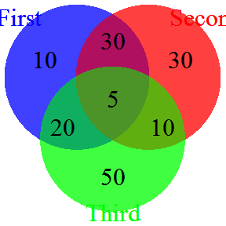

```r
grid.newpage()
grid.draw(draw.triple.venn(
    area1 = 65,
    area2 = 75,
    area3 = 85,
    n12 = 35,
    n23 = 15,
    n13 = 25,
    n123 = 5,
    category = c("First", "Second", "Third"),
    fill = c("blue", "red", "green"),
    lty = "blank",
    cex = 2,
    cat.cex = 2,
    cat.col = c("blue", "red", "green")
))
```

```r
venn_tooltip(
  d3vennR(
    data = list(
        list( sets = list("First"), size = 65),
        list( sets = list("Second"), size = 75),
        list( sets = list("Third"), size = 85),
        list( sets = list( "First", "Second"), size = 35),
        list( sets = list( "Second", "Third" ), size = 15),
        list( sets = list( "First", "Third" ), size = 25),
        list( sets = list( "First", "Second", "Third" ), size = 5)
    )
  )
)
```

[interactive chart not shown]

### `draw.quintuple.venn`

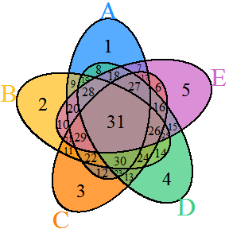

```r
library("VennDiagram")
grid.newpage()
grid.draw(draw.quintuple.venn(
  area1 = 301,
  area2 = 321,
  area3 = 311,
  area4 = 321,
  area5 = 301,
  n12 = 188,
  n13 = 191,
  n14 = 184,
  n15 = 177,
  n23 = 194,
  n24 = 197,
  n25 = 190,
  n34 = 190,
  n35 = 173,
  n45 = 186,
  n123 = 112,
  n124 = 108,
  n125 = 108,
  n134 = 111,
  n135 = 104,
  n145 = 104,
  n234 = 111,
  n235 = 107,
  n245 = 110,
  n345 = 100,
  n1234 = 61,
  n1235 = 60,
  n1245 = 59,
  n1345 = 58,
  n2345 = 57,
  n12345 = 31,
  category = c("A", "B", "C", "D", "E"),
  fill = c("dodgerblue", "goldenrod1", "darkorange1", "seagreen3", "orchid3"),
  cat.col = c("dodgerblue", "goldenrod1", "darkorange1", "seagreen3", "orchid3"),
  cat.cex = 2,
  margin = 0.05,
  cex = c(1.5, 1.5, 1.5, 1.5, 1.5, 1, 0.8, 1, 0.8, 1, 0.8, 1, 0.8, 1, 0.8,
          1, 0.55, 1, 0.55, 1, 0.55, 1, 0.55, 1, 0.55, 1, 1, 1, 1, 1, 1.5),
  ind = TRUE
))
```

```r
venn_tooltip(d3vennR(
  data = list(
    list(sets = list("A"), size = 301),
    list(sets = list("B"), size = 321),
    list(sets = list("C"), size = 311),
    list(sets = list("D"), size = 321),
    list(sets = list("E"), size = 301),
    list(sets = list("A","B"), size = 188),
    list(sets = list("A","C"), size = 191),
    list(sets = list("A","D"), size = 184),
    list(sets = list("A","E"), size = 177),
    list(sets = list("B","C"), size = 194),
    list(sets = list("B","D"), size = 197),
    list(sets = list("B","E"), size = 190),
    list(sets = list("C","D"), size = 190),
    list(sets = list("C","E"), size = 173),
    list(sets = list("D","E"), size = 186),
    list(sets = list("A","B","C"), size = 112),
    list(sets = list("A","B","D"), size = 108),
    list(sets = list("A","B","E"), size = 108),
    list(sets = list("A","C","D"), size = 111),
    list(sets = list("A","C","E"), size = 104),
    list(sets = list("A","D","E"), size = 104),
    list(sets = list("B","C","D"), size = 111),
    list(sets = list("B","C","E"), size = 107),
    list(sets = list("B","D","E"), size = 110),
    list(sets = list("C","D","E"), size = 100),
    list(sets = list("A","B","C","D"), size = 61),
    list(sets = list("A","B","C","E"), size = 60),
    list(sets = list("A","B","D","E"), size = 59),
    list(sets = list("A","C","D","E"), size = 58),
    list(sets = list("B","C","D","E"), size = 57),
    list(sets = list("A","B","C","D","E"), size = 31)
  )
  # feel free to skip this complicated part to match colors
  , colours = htmlwidgets::JS(sprintf('
d3.scale.category10().range(%s.map(function(col){return eval(col)}))
',
      jsonlite::toJSON(lapply(
        c("dodgerblue", "goldenrod1", "darkorange1", "seagreen3", "orchid3")
        ,function(color){
          rgb <- t(col2rgb(color))
          sprintf("d3.rgb(%s)",paste0(rgb,collapse=","))
        }
      ), auto_unbox=T)
    )
  )
  ,layoutFunction = '
function(d) { return venn.venn(d, { initialLayout: venn.classicMDSLayout });}
  '
))
```

[interactive chart not shown]

## Thanks

Thanks so much

- Ben Frederickson for venn.js on which this is based
- [`d3.js`](http://d3js.org) from Mike Bostock
- Ramnath Vaidyanathan and RStudio for `htmlwidgets`
- all the contributors to `R` and `JavaScript`